# lecture_formal_theory

## Become an Agent-Based Model, Round 1

- Don’t look at your card
- Find the highest-value partner who is willing to pair with you
- A handshake is binding: if you shake hands, you’re paired
- Pairs exit the dating market, come to me
- Speaking is not allowed
- You have 90 seconds, like musical chairs: freeze when the alarm rings!

Afterwards, singles show me your card values

## Round 2

- Pairs stay in the market until the end of the game
- Handshakes are not binding

## Round 3

- Look at your card before the game starts

## Analyze scatter

[figure not shown]

## Analyze differences

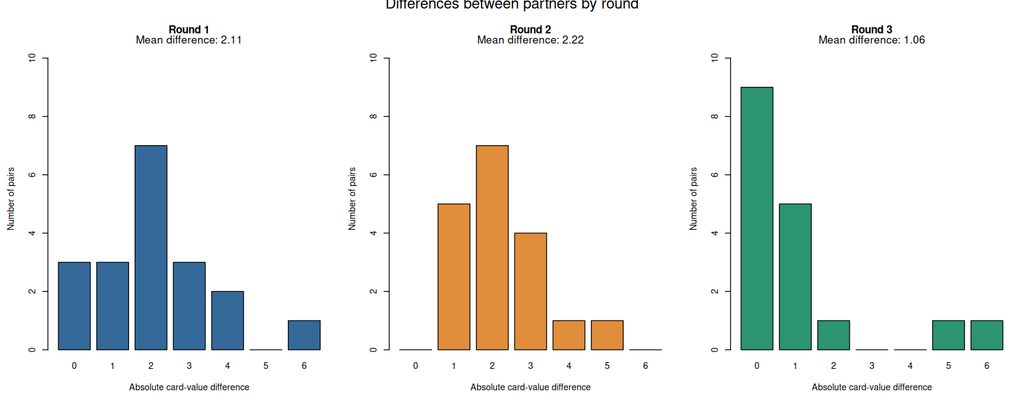

## Analyze differences: total scores

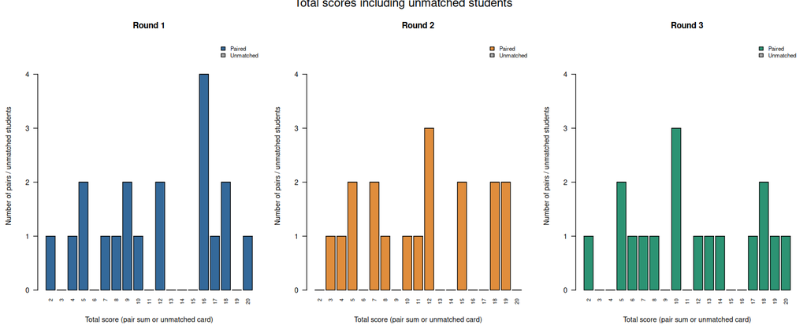

## Formalize the Model

- Groups of 3/4
- Take your experience from the mating game, and design your own agent-based model that could be run by real humans
- You can base it on the theory for your final paper, but don’t have to
- Write instructions for your humans
- Then, present to the class

## Question the Model

Suggested phrasing of your questions:

“What I learned from your model is X, what I still wonder about is Y”

Suggested lines of inquiry:

1. What aspects of the exercise do you miss?
2. Which assumptions are unrealistic or unjustified?
3. When would the model likely fail/what would break it?

## Reflection

1. What did you learn about formal modeling?
2. Which activity or reading most did you find most informative?
3. What is one unresolved question you have about formal modeling?